# 4th Floor Fantasy Draft 2022

Evan Oman

September 2, 2022

## Introduction

The analysis below explores the performance of my friends during our 2022 Fantasy Football Draft. Since 2016 we have been drafting in a no-cheatsheet environment which means that each drafter must know who they are going to draft before the draft starts. As such the performance of each drafter could vary wildly and is thus an interesting phenomena to explore.

Note that I am using the ESPN Superflex PPR rankings as a proxy for ground truth. Many of the rankings there are debatable but I think overall it gives a good rough estimate of each player’s value.

The source and data for this project are available at https://github.com/EvanOman/FantasyFootball. My contact info is available on my website: http://www.evanoman.com.

Let the fun begin!

## Data Preparation

First we load in the draft data. This year I was able to copy the data from the ESPN website and reformat it with a few regular expressions.

We load the data here:

```r
draftData <- read.csv("./data/Draft2022.csv", stringsAsFactors = F)
print.data.frame(head(draftData), row.names=FALSE)
```

```
##  PickNumber          Player Drafter Round
##           1      Josh Allen    Evan     1
##          16     Cooper Kupp    Evan     2
##          17    Dak Prescott    Evan     3
##          32    Deebo Samuel    Evan     4
##          33     CeeDee Lamb    Evan     5
##          48  Russell Wilson    Evan     6
```

This year the data is already in the tall format we want so we can move on to incorporating the rankings.

For 2022 we will be using the top 300 ESPN PPR Superflex rankings

```r
rankings <- read.csv("./data/espn_superflex_ppr_2022.csv", stringsAsFactors = F)

# Read player as string, not factor
rankings$Player <- as.character(rankings$Player)

print.data.frame(head(rankings, n=10), row.names=FALSE)
```

```
##  Rank Pos               Player Team
##     1  QB           Josh Allen  BUF
##     2  QB      Patrick Mahomes   KC
##     3  QB       Justin Herbert  LAC
##     4  RB      Jonathan Taylor  IND
##     5  QB        Lamar Jackson  BAL
##     6  RB  Christian McCaffrey  CAR
##     7  QB         Kyler Murray  ARI
##     8  WR          Cooper Kupp  LAR
##     9  QB          Jalen Hurts  PHI
##    10  RB        Austin Ekeler  LAC
```

This dataset is already in the tall format we want so there will be no reformating needed. With all of the data prepared we can just join `draftData` with `rankings` by `Player`. Note that this is a left join by default so the resulting dataframe will only contain rows from our draft dataframe. The ranking dataset only includes the top 300 players. Thus some players will not have a ranking so after the join these players will have a `NA` rank. We will replace this with the worst possible ranking (`nrow(rankings)`) plus `1`.

```r
library("dplyr")
```

[output not shown]

```r
# Join rankings data with draft data
joinedData <- left_join(draftData, rankings, by="Player")

# Some players will not have a  ranking, give these players a worst ranking + 1
joinedData$Rank[is.na(joinedData$Rank)] <- nrow(rankings) + 1

print.data.frame(head(joinedData, n=10), row.names=FALSE)
```

```
##  PickNumber            Player Drafter Round Rank Pos Team
##           1        Josh Allen    Evan     1    1  QB  BUF
##          16       Cooper Kupp    Evan     2    8  WR  LAR
##          17      Dak Prescott    Evan     3   11  QB  DAL
##          32      Deebo Samuel    Evan     4   22  WR   SF
##          33       CeeDee Lamb    Evan     5   28  WR  DAL
##          48    Russell Wilson    Evan     6   20  QB  DEN
##          49      Alvin Kamara    Evan     7   19  RB   NO
##          64  Javonte Williams    Evan     8   32  RB  DEN
##          65      James Conner    Evan     9   34  RB  ARI
##          80       Kareem Hunt    Evan    10   94  RB  CLE
```

We now have a dataframe with each draft pick with the corresponding pick number and player ranking. We can then use the pick number and player ranking to measure the quality of each draft pick.

```r
joinedData$RankDiff <- joinedData$Rank - joinedData$PickNumber

print.data.frame(head(joinedData, n=10), row.names=FALSE)
```

```
##  PickNumber            Player Drafter Round Rank Pos Team RankDiff
##           1        Josh Allen    Evan     1    1  QB  BUF        0
##          16       Cooper Kupp    Evan     2    8  WR  LAR       -8
##          17      Dak Prescott    Evan     3   11  QB  DAL       -6
##          32      Deebo Samuel    Evan     4   22  WR   SF      -10
##          33       CeeDee Lamb    Evan     5   28  WR  DAL       -5
##          48    Russell Wilson    Evan     6   20  QB  DEN      -28
##          49      Alvin Kamara    Evan     7   19  RB   NO      -30
##          64  Javonte Williams    Evan     8   32  RB  DEN      -32
##          65      James Conner    Evan     9   34  RB  ARI      -31
##          80       Kareem Hunt    Evan    10   94  RB  CLE       14
```

At this point all of the data has been prepped so we are ready to generate some plots and do a bit of analysis.

## Figures and Results

Probably the most natural measure of performance would be to look at the average difference between pick number and rank, across all rounds, organized by Drafter. We can calculate this using `aggregate`.

```r
avgDiffs <- aggregate(RankDiff ~ Drafter, joinedData, FUN=mean)

# Order factor by worst draft to best
avgDiffs <- within(avgDiffs, Drafter <- factor(Drafter, levels=avgDiffs[order(avgDiffs$RankDiff), "Drafter"]))

# Order dataframe by worst draft to best
avgDiffs <- avgDiffs[order(avgDiffs$RankDiff, decreasing = FALSE),]

print.data.frame(avgDiffs, row.names=FALSE)
```

```
##   Drafter RankDiff
##     Chris     4.15
##      Will     8.15
##      Evan    15.50
##    Andrew    17.95
##     Jacob    17.95
##    Joseph    26.25
##   Michael    31.50
##    Kuuuby    89.80
```

Thus we can see that Chris had the best draft (on average he got players 4.15 positions over rank value) and Kuuuby had the worst (on average, he got players 89.8 positions over rank value). Here is a quick visual of the above dataframe.

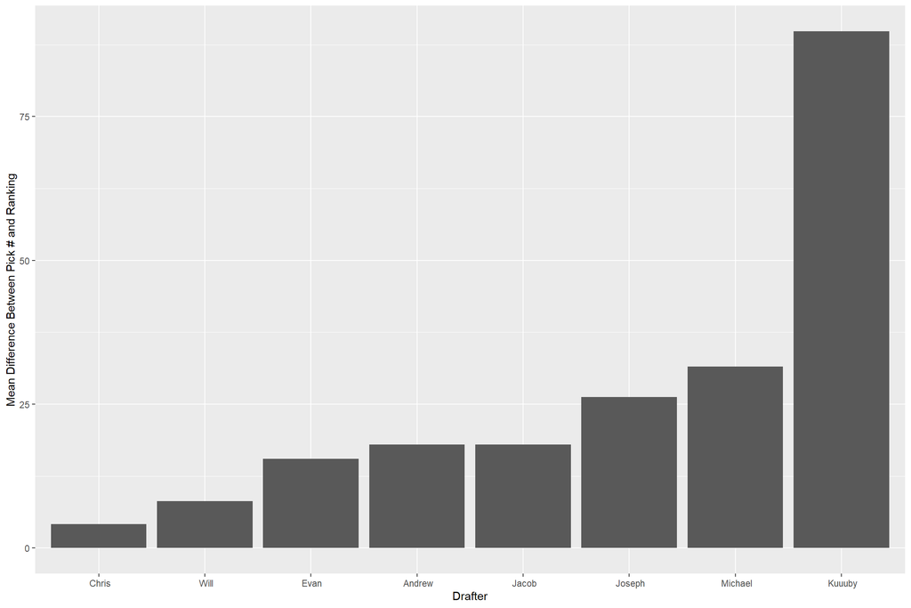

```r
library(ggplot2)
ggplot(avgDiffs, aes(x=Drafter, y=RankDiff)) + geom_bar(stat = "identity") + ylab("Mean Difference Between Pick # and Ranking")
```

Since kickers and defenses are generally ranked very low, and because I picked a bad kicker and defense, I was curious to see what these rankings look like without those position types:

```r
noKorDst <- joinedData[!(joinedData$Pos %in% list("DST", "K")), ]

avgDiffs2 <- aggregate(RankDiff ~ Drafter, noKorDst, FUN=mean)

# Order factor by worst draft to best
avgDiffs2 <- within(avgDiffs2, Drafter <- factor(Drafter, levels=avgDiffs[order(avgDiffs$RankDiff), "Drafter"]))

# Order dataframe by worst draft to best
avgDiffs2 <- avgDiffs2[order(avgDiffs2$RankDiff, decreasing = FALSE),]

print.data.frame(avgDiffs2, row.names=FALSE)
```

[output not shown]

I was curious to see how undervalued/overvalued players were by position. We can use a similar methodology as above to figure this out.

```r
posDiffs <- aggregate(RankDiff ~ Pos, joinedData, FUN=mean)

posDiffs <- within(posDiffs, Pos <- factor(Pos, levels=posDiffs[order(posDiffs$RankDiff), "Pos"]))

# Order dataframe by worst draft to best
posDiffs <- posDiffs[order(posDiffs$RankDiff, decreasing = FALSE),]

print.data.frame(posDiffs, row.names=FALSE)
```

```
##   Pos   RankDiff
##    QB -12.238095
##    RB   3.880952
##    WR   8.407407
##    TE  43.200000
##   DST  67.125000
##     K  75.500000
```

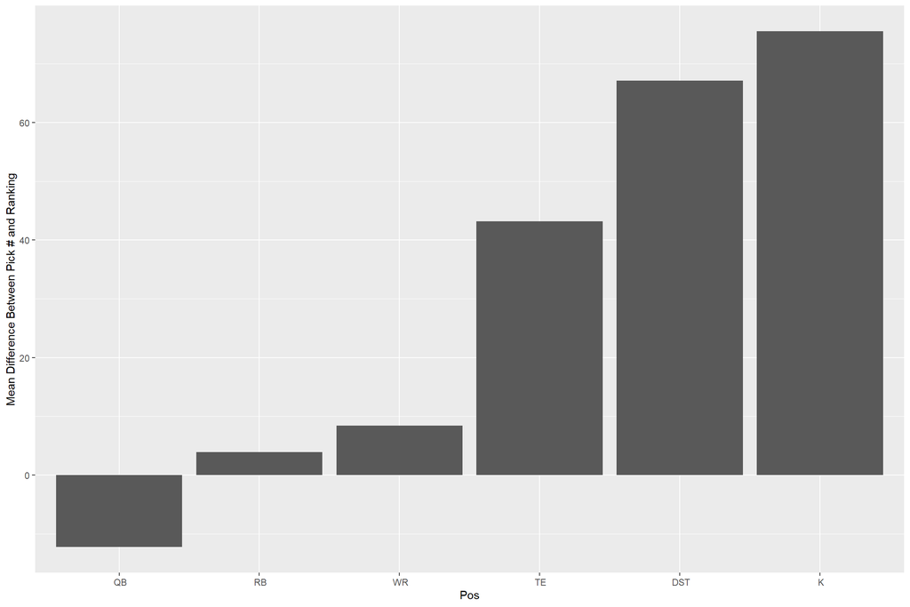

```r
ggplot(posDiffs, aes(x=Pos, y=RankDiff)) + geom_bar(stat = "identity") + ylab("Mean Difference Between Pick # and Ranking")
```

Here we can see that QB were under valued by 12.2380952 positions and K were overvalued by 75.5 positions.

I was also curious to see how draft pick quality changed by round. In the next two figures I am plotting `Pick #` vs `Rank` with a diagonal line indicating a pick at the rank value. Thus all picks below this line are “good” and all of the above are “bad”. In the first figure I colored the picks by Drafter and in the second I am coloring by position.

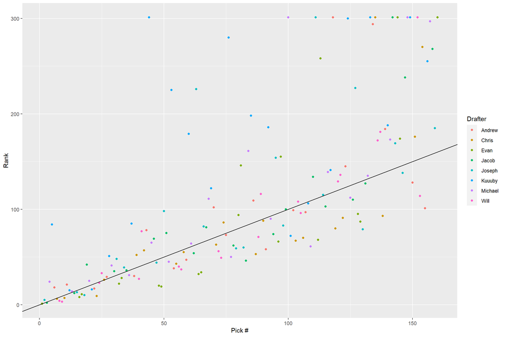

```r
# Scatter colored by drafter
ggplot(joinedData, aes(x=PickNumber,y=Rank)) + geom_point(aes(color=Drafter)) + geom_abline() + xlab("Pick #")
```

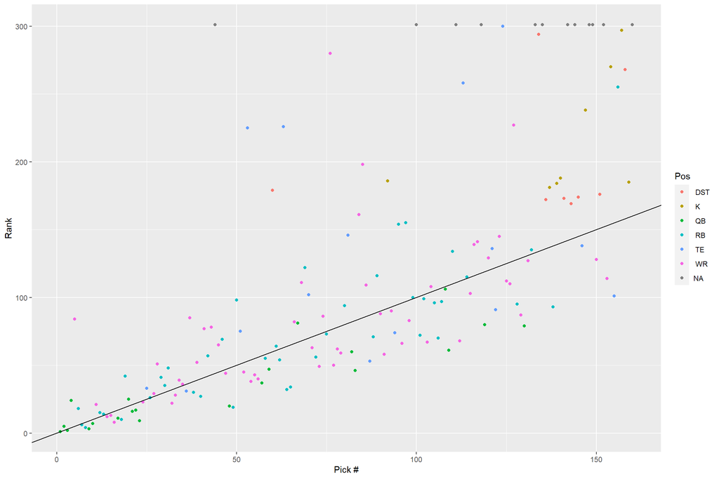

```r
# Scatter colored by position
ggplot(joinedData, aes(x=PickNumber,y=Rank)) + geom_point(aes(color=Pos)) + geom_abline() + xlab("Pick #")
```

It is pretty clear that as time goes on, worse and worse picks made.

Finally I wanted to see how each drafter performed by round, the following figure accomplishes this (here any pick below the dashed line is “good” and anything above the dashed line is “bad”).

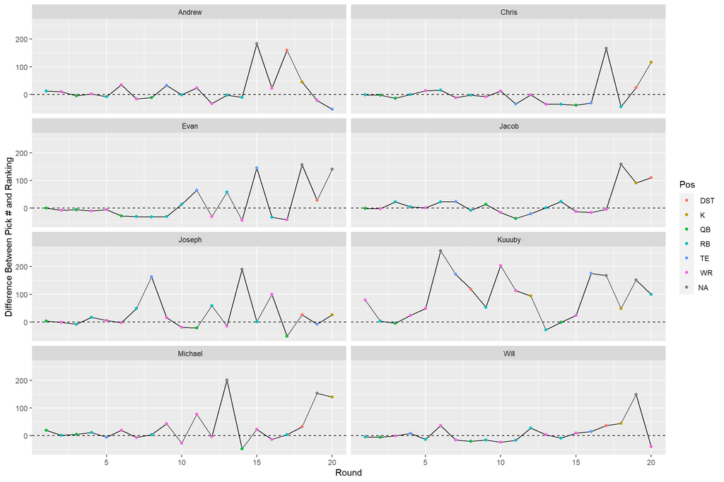

```r
# Scatter colored by position, faceted by drafer
ggplot(joinedData, aes(x=Round, y=RankDiff)) + geom_line() + facet_wrap(~Drafter, ncol=2) + geom_hline(yintercept = 0, linetype=2) + geom_point(aes(color=Pos)) + ylab("Difference Between Pick # and Ranking")
```

## Conclusion

Here are some final take aways:

- **Best Draft:** Chris (avg pick 4.15 positions over rank value)
- **Worst Draft:** Kuuuby (avg pick 89.8 positions over rank value)
- **Best Pick:** Drafter: Andrew, Round: 20, Player: Dallas Goedert, Rank Difference: -54
- **Worst Pick:** Drafter: Kuuuby, Round: 6, Player: Aaron Donald, Rank Difference: 257